# 7. Propiedades de la potenciación y radicación

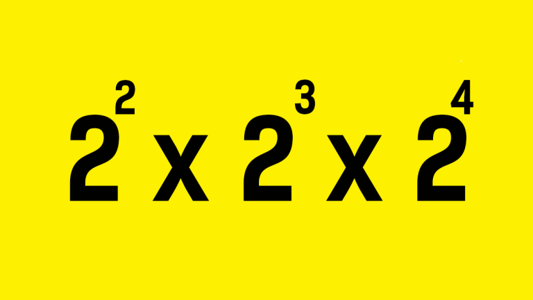

Fuente: yosoytuprofe.20minutos.es

## Propiedades de las potencias

Estas propiedades **nos ayudan a no hacer todo el cálculo paso a paso**. Sirven para pensar más rápido.

Puedes repasar estos temas viendo este [video](https://www.youtube.com/watch?v=lW7-VAfCZSI)

### a. Producto de potencias de igual base

$$a^m \times a^n = a^{m+n}$$

**Ejemplo:**

$$2^3 \times 2^4 = 2^{3+4} = 2^7 = 128$$

### b. Cociente de potencias de igual base

$$a^m \div a^n = a^{m-n}
\quad \text{(si } m \geq n \text{)}$$

**Ejemplo:**

$$5^6 \div 5^2 = 5^{6-2} = 5^4 = 625$$

### c. Potencia de potencia

$$(a^m)^n = a^{m \cdot n}$$

**Ejemplo:**

$$(3^2)^3 = 3^{2 \cdot 3} = 3^6 = 729$$

## Actividad 1

Resolver aplicando las propiedades y sin usar calculadora

- $10^6 \div 10^4$
- $2^2 \times 2^1$
- $(2^2)^2$
- $8^8 \div 8^5$
- $3^2 \times 3^2$
- $(2^3)^2$

## Propiedad distributiva de la potenciación

### a. Propiedad distributiva respecto a la multiplicación

$$(a \cdot b)^n = a^n \cdot b^n$$

**Ejemplo:**

$$(2 \cdot 5)^3 = 2^3 \cdot 5^3 = 8 \cdot 125 = 1000$$

### b. Propiedad distributiva respecto a la división

$$\left(\frac{a}{b}\right)^n = \frac{a^n}{b^n}
\quad \text{(si } b \neq 0 \text{)}$$

**Ejemplo:**

$$\left(\frac{4}{2}\right)^2 = \frac{4^2}{2^2} = \frac{16}{4} = 4$$

## Actividad 2

Resolver aplicando la propiedad distributiva sin usar calculadora

- $(2 \cdot 3)^2$
- $\left(\frac{6}{3}\right)^2$
- $(4 \cdot 5)^2$
- $\left(\frac{10}{3}\right)^3$

## Uso de calculadora

Usamos la calculadora para:

- Verificar resultados
- Calcular potencias o raíces complicadas
- Comparar o explorar valores rápidamente

**Ejemplo con calculadora:** ¿Cuánto da $3^{8}$? Ingresás: `3`, botón `^`, luego `8`, y obtenés: **≈ 6561**

Puedes repasar [aquí](https://www.youtube.com/watch?v=g-dKVZcIhDU) el uso de la calculadora para calcular potencias y [aquí](https://www.youtube.com/watch?v=ZjkX2pjhn0Q) para calcular raíces.

## Actividad 3 (Con calculadora)

1. Comprobá con la calculadora si estas igualdades son verdaderas:
   - $2^3 \cdot 2^2 = 2^5$
   - $(4 \cdot 2)^2 = 4^2 \cdot 2^2$
   - $(3^2)^2 = 3^4$
2. Explorá: ¿cuánto crece un número cuando lo elevás?
   - Proba: $1.01^5$, $1.01^{10}$, $1.01^{50}$
   - ¿Qué observás?

## Ejercicios combinados

Para resolver los ejercicios debes seguirlas reglas del “orden de las operaciones”:

- 1° Resolver los paréntesis
- 2° Resolver potencias y raices
- 3° Resolver multiplicaciones y divisiones
- 4° Resolver sumas y restas

También puedes repasar esto [aquí](https://www.youtube.com/watch?v=KZRvpkmNNf8)

## Actividad 4

Ejercicios combinados con potencias y raíces. Hacerlos paso a paso. Usar la calculadora para comprobar resultados.

- 1. $2^3 + \sqrt{36} \cdot 2$
- 2. $(3 + 2)^2 - \sqrt{49}$
- 3. $\sqrt{64} + 5^2 \div 5$
- 4. $10 + (2^2 \cdot 3) - \sqrt{25}$
- 5. $(4^2 + 2^3) \div (1 + \sqrt{9})$

### Usando propiedades

- 6. $2^3 \cdot 2^2 + \sqrt{36}$
- 7. $\left( \frac{3^4}{3^2} \right) + 2^2 \cdot \sqrt{16}$
- 8. $(2^2)^3 - \sqrt{25} \cdot 3$
- 9. $(4 \cdot 2)^2 - 2^3 + \sqrt{64}$
- 10. $\left( \frac{10}{2} \right)^2 + \frac{2^5}{2^2}$

### Otros más desafiantes

- 1. $\left( 2^3 + \sqrt{16} \right) \cdot (6 - 2)$
- 2. $\left( \sqrt{9} + 2 \right)^2 - 2^3$
- 3. $\left( \frac{4^2 + 3^2}{\sqrt{25}} \right) + \left( 2^3 - \sqrt{16} \right)$
- 4. $\left( 3^3 - \sqrt{49} + 1 \right)^2 \div \left( 2^2 + \sqrt{36} \right)$